# 👩‍💻 **Sample from a VAE and an Autoregressive Model**

## 📋 **Overview**

This activity will guide you through the implementation and exploration of two vital generative models in AI: Variational Autoencoders (VAEs) and Autoregressive Models. These models are fundamental in generating diverse types of data. You will gain a comprehensive understanding by building and experimenting with these models using PyTorch.

- Apply the learned theory to practical coding.
- Understand the distinct generative processes for different data types.
- Recognize real-world applications of VAEs and autoregressive models.

## 🎯 **Learning Outcomes**

By the end of this lab, you will be able to:

- Construct and train a Variational Autoencoder (VAE) using the MNIST dataset.
- Implement a character-level Autoregressive Model for sequence generation.
- Compare and critique the outputs of VAEs and Autoregressive Models in terms of diversity and coherence.

## Imports and Starter Code

```python
# imports
import torch
import torch.nn as nn
import torch.optim as optim
from torchvision import datasets, transforms
from torch.utils.data import DataLoader, TensorDataset
import torch.nn.functional as F
import matplotlib.pyplot as plt
import pandas as pd
import numpy as np

# Data loading helper function (provided for you)
def load_mnist_from_csv(csv_path='mnist_train.csv'):
    """Load MNIST data from CSV file - this handles the data loading for you"""
    print("Loading MNIST data from CSV...")

    try:
        # Read the CSV file
        df = pd.read_csv(csv_path)
        print(f"CSV loaded successfully. Shape: {df.shape}")

        # Handle different possible CSV structures
        if df.shape[1] == 785:  # 784 pixels + 1 label (common format)
            labels = df.iloc[:, 0].values
            pixels = df.iloc[:, 1:].values
        elif 'label' in df.columns:
            labels = df['label'].values
            pixel_cols = [col for col in df.columns if col != 'label']
            pixels = df[pixel_cols].values
        else:
            labels = df.iloc[:, 0].values
            pixels = df.iloc[:, 1:].values

        # Ensure we have 784 pixels per image
        if pixels.shape[1] != 784:
            if pixels.shape[1] > 784:
                pixels = pixels[:, :784]
            else:
                padding = np.zeros((pixels.shape[0], 784 - pixels.shape[1]))
                pixels = np.concatenate([pixels, padding], axis=1)

        # Normalize and convert to tensors
        pixels = pixels.astype(np.float32)
        if pixels.max() > 1.0:
            pixels = pixels / 255.0

        pixel_tensor = torch.from_numpy(pixels)
        label_tensor = torch.from_numpy(labels.astype(np.int64))

        print(f"Successfully processed {len(pixel_tensor)} samples")
        return pixel_tensor, label_tensor

    except Exception as e:
        print(f"CSV loading failed: {e}")
        print("Creating synthetic MNIST-like data as fallback...")
        n_samples = 5000
        pixels = torch.rand(n_samples, 784) * 0.5 + 0.25
        labels = torch.randint(0, 10, (n_samples,))
        return pixels, labels

# Load MNIST data from CSV (this replaces the usual torchvision download)
train_data, train_labels = load_mnist_from_csv('mnist_train.csv')
train_dataset = TensorDataset(train_data, train_labels)
train_loader = DataLoader(train_dataset, batch_size=128, shuffle=True)

print(f"✅ Dataset ready: {len(train_dataset)} samples loaded")
```

```
Loading MNIST data from CSV...
CSV loaded successfully. Shape: (60000, 785)
Successfully processed 60000 samples
✅ Dataset ready: 60000 samples loaded
```

## Task 1: Build and Explore a VAE [30 minutes]

Construct a simple VAE using PyTorch to work with the MNIST dataset. The model will map input images to a latent distribution, then reconstruct images for visualization.

**Note:** We've provided you with data loading code that reads MNIST from a CSV file instead of downloading it from the internet. The `train_dataset` and `train_loader` variables are already created for you in the imports section above.

1. Train the VAE using the provided training loop.
2. Sample new images from the latent space and visualize using matplotlib.
3. Compare the generated images with original MNIST images.

```
Starting VAE training...
Epoch 0, Loss: 12209.2070
Epoch 2, Loss: 11244.1660
Epoch 4, Loss: 11082.8477
Epoch 6, Loss: 11106.4746
Epoch 8, Loss: 10171.0293
VAE training completed!
```

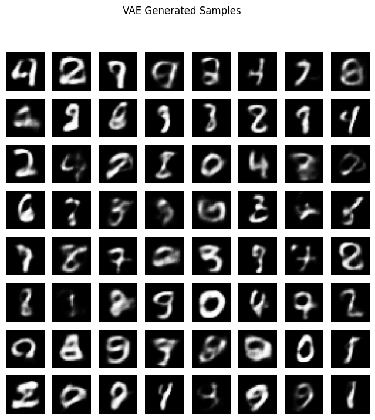

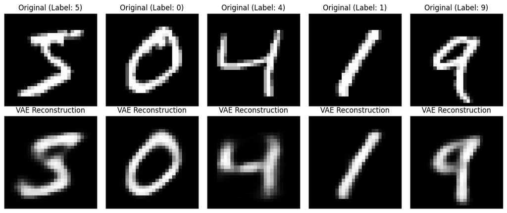

```python
class VAE(nn.Module):
    def __init__(self):
        super(VAE, self).__init__()
        self.encoder = nn.Sequential(
            nn.Linear(784, 400),
            nn.ReLU(),
            nn.Linear(400, 20)  # output: mean and logvar
        )
        self.decoder = nn.Sequential(
            nn.Linear(10, 400),
            nn.ReLU(),
            nn.Linear(400, 784),
            nn.Sigmoid()
        )

    def encode(self, x):
        h1 = self.encoder(x)
        return h1[:, :10], h1[:, 10:]

    def reparameterize(self, mu, logvar):
        std = torch.exp(0.5 * logvar)
        eps = torch.randn_like(std)
        return mu + eps * std

    def decode(self, z):
        return self.decoder(z)

    def forward(self, x):
        mu, logvar = self.encode(x)
        z = self.reparameterize(mu, logvar)
        return self.decode(z), mu, logvar

# Note: train_dataset and train_loader are already loaded from CSV in the imports section

# VAE Training
model = VAE()
optimizer = optim.Adam(model.parameters(), lr=1e-3)

def loss_function(recon_x, x, mu, logvar):
    BCE = F.binary_cross_entropy(recon_x, x, reduction='sum')
    KLD = -0.5 * torch.sum(1 + logvar - mu.pow(2) - logvar.exp())
    return BCE + KLD

print("Starting VAE training...")
for epoch in range(10):
    for batch_idx, (data, _) in enumerate(train_loader):
        optimizer.zero_grad()
        recon_batch, mu, logvar = model(data)
        loss = loss_function(recon_batch, data, mu, logvar)
        loss.backward()
        optimizer.step()

    if epoch % 2 == 0:
        print(f'Epoch {epoch}, Loss: {loss.item():.4f}')

print("VAE training completed!")

# Generate samples
with torch.no_grad():
    sample = torch.randn(64, 10)
    sample = model.decode(sample).cpu()

# Visualization
fig, axes = plt.subplots(8, 8, figsize=(8, 8))
for i, ax in enumerate(axes.flat):
    ax.imshow(sample[i].view(28, 28), cmap='gray')
    ax.axis('off')
plt.suptitle('VAE Generated Samples')
plt.show()

# Compare with original data
fig, axes = plt.subplots(2, 5, figsize=(12, 5))

# Show original images
for i in range(5):
    axes[0, i].imshow(train_data[i].view(28, 28), cmap='gray')
    axes[0, i].set_title(f'Original (Label: {train_labels[i]})')
    axes[0, i].axis('off')

# Show reconstructions
model.eval()
with torch.no_grad():
    test_input = train_data[:5]
    recon, _, _ = model(test_input)
    for i in range(5):
        axes[1, i].imshow(recon[i].view(28, 28), cmap='gray')
        axes[1, i].set_title('VAE Reconstruction')
        axes[1, i].axis('off')

plt.tight_layout()
plt.show()
```

✅ **Success Checklist**

- The VAE can reconstruct MNIST images reliably.
- Samples from the latent space show variability and quality similar to real images.

💡 **Key Points**

- Understand the encoder/decoder process in VAEs.
- Recognize how latent space sampling affects image generation.

❗ **Common Mistakes to Avoid**

- Incorrect dimension matching in encoder/decoder operations.
- Not implementing the reparameterization trick properly.
- Using inappropriate loss functions or balancing reconstruction vs KL divergence loss.